# CS422 Section 01

Kaiyue Ma

# 2.1

```r
library(rpart)
library(caret)
library(rpart.plot)
library(ROCR)
library(lattice)
library(ggplot2)
set.seed(1122)
setwd("/Users/michael/Codes/R/2")
train <- read.csv("adult-train.csv", header=T, sep=",")
test <- read.csv("adult-test.csv", header=T, sep=",")
```

### (a)

```r
#bulid the pure set
train[train=="?"]<-NA
pure_train <- na.omit(train)
test[test=="?"]<-NA
pure_test <- na.omit(test)
```

### (b)

```r
#bulid the tree
model_income <- rpart(pure_train$income ~., method="class", data = pure_train)
print(model_income)
```

```
n= 30161

node), split, n, loss, yval, (yprob)
      * denotes terminal node

 1) root 30161 7508 <=50K (0.751069 0.248931)
   2) relationship=Not-in-family,Other-relative,Own-child,Unmarried 16292 1135 <=50K (0.930334 0.069666)
     4) capital_gain< 7073.5 15992  845 <=50K (0.947161 0.052839) *
     5) capital_gain>=7073.5 300   10 >50K (0.033333 0.966667) *
   3) relationship=Husband,Wife 13869 6373 <=50K (0.540486 0.459514)
     6) education=10th,11th,12th,1st-4th,5th-6th,7th-8th,9th,Assoc-acdm,Assoc-voc,HS-grad,Preschool,Some-college 9719 3322 <=50K (0.658195 0.341805)
      12) capital_gain< 5095.5 9219 2831 <=50K (0.692917 0.307083) *
      13) capital_gain>=5095.5 500    9 >50K (0.018000 0.982000) *
     7) education=Bachelors,Doctorate,Masters,Prof-school 4150 1099 >50K (0.264819 0.735181) *
```

```r
summary(model_income)
```

```
Call:
rpart(formula = pure_train$income ~ ., data = pure_train, method = "class")
  n= 30161

        CP nsplit rel error  xerror      xstd
1 0.129995      0   1.00000 1.00000 0.0100018
2 0.064198      2   0.74001 0.74001 0.0089670
3 0.037294      3   0.67581 0.67581 0.0086527
4 0.010000      4   0.63852 0.63852 0.0084574

Variable importance
  relationship marital_status   capital_gain      education  education_num            sex     occupation
            24             23             10              9              9              8              7
           age hours_per_week
             5              3

Node number 1: 30161 observations,    complexity param=0.12999
  predicted class=<=50K  expected loss=0.24893  P(node) =1
    class counts: 22653  7508
   probabilities: 0.751 0.249
  left son=2 (16292 obs) right son=3 (13869 obs)
  Primary splits:
      relationship   splits as  RLLLLR, improve=2277.2, (0 missing)
      marital_status splits as  LRRLLLL, improve=2244.4, (0 missing)
      capital_gain   < 5119   to the left,  improve=1540.8, (0 missing)
      education      splits as  LLLLLLLLLRRLRLRL, improve=1193.8, (0 missing)
      education_num  < 12.5   to the left,  improve=1193.8, (0 missing)
  Surrogate splits:
      marital_status splits as  LRRLLLL, agree=0.993, adj=0.984, (0 split)
      sex            splits as  LR, agree=0.691, adj=0.328, (0 split)
      age            < 33.5   to the left,  agree=0.645, adj=0.229, (0 split)
      occupation     splits as  -LLRRRLLLLRRLLR, agree=0.620, adj=0.175, (0 split)
      hours_per_week < 43.5   to the left,  agree=0.604, adj=0.138, (0 split)

Node number 2: 16292 observations,    complexity param=0.037294
  predicted class=<=50K  expected loss=0.069666  P(node) =0.54017
    class counts: 15157  1135
   probabilities: 0.930 0.070
  left son=4 (15992 obs) right son=5 (300 obs)
  Primary splits:
```

[output cut: 45 more lines]

```

Node number 7: 4150 observations
  predicted class=>50K   expected loss=0.26482  P(node) =0.13759
    class counts:  1099  3051
   probabilities: 0.265 0.735

Node number 12: 9219 observations
  predicted class=<=50K  expected loss=0.30708  P(node) =0.30566
    class counts:  6388  2831
   probabilities: 0.693 0.307

Node number 13: 500 observations
  predicted class=>50K   expected loss=0.018  P(node) =0.016578
    class counts:     9   491
   probabilities: 0.018 0.982
```

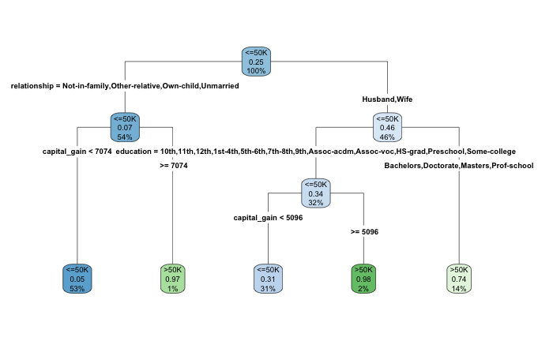

```r
rpart.plot(model_income, fallen.leaves = T, type = 4)
```

#### (i) The top three important predictors in the model are : relationship, marital_status and capital_gain.

#### (ii) The first split is done on predictor Relationship.

#### The predicted class of the first node is ‘<=50K’.

#### Distribution of observations between the “<=50K” and “>50K” classes at this node is 0.75106926 and 0.24893074.

### (c)

```r
#predict
pred <- predict(model_income, pure_test, type="class")
```

```r
test_num_pos <- sum(pure_test$income == ">50K")
test_num_neg <- sum(pure_test$income == "<=50K")
tp <- sum(pure_test$income == ">50K" & pred == ">50K")
tn <- sum(pure_test$income == "<=50K" & pred == "<=50K")
table(pred, pure_test$income)
```

```
pred    <=50K  >50K
  <=50K 10772  1837
  >50K    588  1863
```

```r
confusionMatrix(pred, pure_test$income)
```

```
Confusion Matrix and Statistics

          Reference
Prediction <=50K  >50K
     <=50K 10772  1837
     >50K    588  1863

               Accuracy : 0.839
                 95% CI : (0.833, 0.845)
    No Information Rate : 0.754
    P-Value [Acc > NIR] : <2e-16

                  Kappa : 0.51
 Mcnemar's Test P-Value : <2e-16

            Sensitivity : 0.948
            Specificity : 0.504
         Pos Pred Value : 0.854
         Neg Pred Value : 0.760
             Prevalence : 0.754
         Detection Rate : 0.715
   Detection Prevalence : 0.837
      Balanced Accuracy : 0.726

       'Positive' Class : <=50K
```

#### (i) The balanced accuracy of the model is 0.726.

#### (ii) The balanced error rate of the model is 0.274.

#### (iii) Sensitivity : 0.948 Specificity : 0.504

#### (iv)

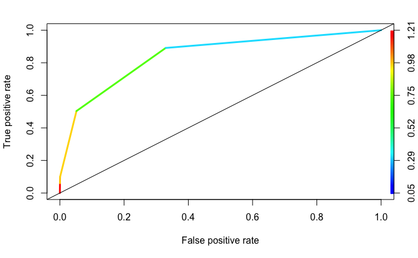

```r
# ROC curve
pred.rocr <- predict(model_income, newdata=pure_test, type="prob")[,2]
f.pred <- prediction(pred.rocr, pure_test$income)
f.perf <- performance(f.pred, "tpr", "fpr")
plot(f.perf, colorize=T, lwd=3)
abline(0,1)
```

```r
auc <- performance(f.pred, measure = "auc")
cat(paste("The area under curve (AUC) for this model is ", round(auc@y.values[[1]], 3)))
```

```
The area under curve (AUC) for this model is  0.843
```

#### The area under curve (AUC) for this model is 0.843

### (d)

```r
options("digits"=5)
printcp(model_income)
```

```
Classification tree:
rpart(formula = pure_train$income ~ ., data = pure_train, method = "class")

Variables actually used in tree construction:
[1] capital_gain education    relationship

Root node error: 7508/30161 = 0.249

n= 30161

      CP nsplit rel error xerror    xstd
1 0.1300      0     1.000  1.000 0.01000
2 0.0642      2     0.740  0.740 0.00897
3 0.0373      3     0.676  0.676 0.00865
4 0.0100      4     0.639  0.639 0.00846
```

#### The tree won’t benefit from a pruning, it will not significant benefit the tree. Because the 4th line’s xerror rate is the smallest in the CP table. Look down from the first line the xerror rate it didn’t increase.

### (e)

```r
#number
train_num_pos <- sum(pure_train$income == ">50K")
train_num_neg <- sum(pure_train$income == "<=50K")
```

#### (i) The numver of observations are in the class “<=50K” is : 22653

#### The numver of observations are in the class “>50K” is : 7508

#### (ii)

```r
#sample
temp_neg <- pure_train[pure_train$income == "<=50K",]
sample_pos <- temp_neg[sample(nrow(temp_neg), train_num_pos, replace = F), ]
#merge
train_pos <- pure_train[which(pure_train$income == ">50K"),]
new_train <- rbind(train_pos, sample_pos)
#random
new_train <- new_train[sample(nrow(new_train), nrow(new_train), replace = F),]
```

#### (iii)

```r
new_model_income <- rpart(new_train$income ~., method="class", data = new_train)
```

```r
new_pred <- predict(new_model_income, pure_test, type="class")
confusionMatrix(new_pred, pure_test$income)
```

```
Confusion Matrix and Statistics

          Reference
Prediction <=50K >50K
     <=50K  8879  609
     >50K   2481 3091

               Accuracy : 0.795
                 95% CI : (0.788, 0.801)
    No Information Rate : 0.754
    P-Value [Acc > NIR] : <2e-16

                  Kappa : 0.527
 Mcnemar's Test P-Value : <2e-16

            Sensitivity : 0.782
            Specificity : 0.835
         Pos Pred Value : 0.936
         Neg Pred Value : 0.555
             Prevalence : 0.754
         Detection Rate : 0.590
   Detection Prevalence : 0.630
      Balanced Accuracy : 0.809

       'Positive' Class : <=50K
```

###### (i) The balanced accuracy of the model is 0.809.

###### (ii) The balanced error rate of the model is 0.191.

###### (iii) Sensitivity : 0.782 Specificity : 0.835

###### (iv)

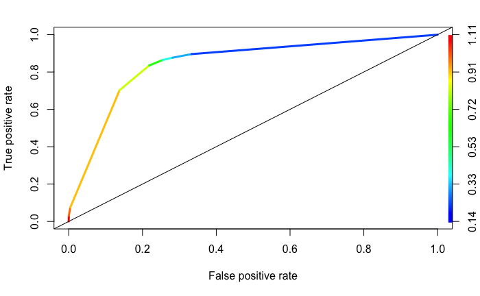

```r
# ROC curve
pred.rocr <- predict(new_model_income, newdata=pure_test, type="prob")[,2]
f.pred <- prediction(pred.rocr, pure_test$income)
f.perf <- performance(f.pred, "tpr", "fpr")
plot(f.perf, colorize=T, lwd=3)
abline(0,1)
```

```r
auc <- performance(f.pred, measure = "auc")
cat(paste("The area under curve (AUC) for this model is ", round(auc@y.values[[1]], 3)))
```

```
The area under curve (AUC) for this model is  0.846
```

##### The area under curve (AUC) for this model is 0.846

### (f)

#### In(C): The Balanced accuracy of the model is 0.726, the Sensitivity is 0.948 and the Specificity is 0.504 and the area under curve (AUC) for this model is 0.843.

#### In(e): The balanced accuracy of the model is 0.809, the Sensitivity is 0.782 and the Specificity is 0.835 and the area under curve (AUC) for this model is 0.846.

#### It shows that the Balanced accuracy and Specificity are increasing but the Sensitivity is decreasing. The area under curve(AUC) has little change.

# 2.2

```r
library(randomForest)
```

### (a)

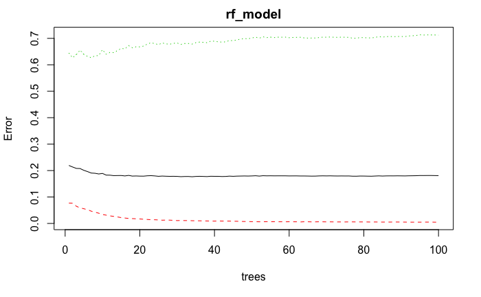

```r
rf_model <- randomForest(income ~ ., data=pure_train, ntree = 100, importance = T)
plot(rf_model)
```

```r
rf_pred <- predict(rf_model, pure_test, type="class")
confusionMatrix(rf_pred, as.factor(pure_test$income))
```

```
Confusion Matrix and Statistics

          Reference
Prediction <=50K  >50K
     <=50K 11324  2690
     >50K     36  1010

               Accuracy : 0.819
                 95% CI : (0.813, 0.825)
    No Information Rate : 0.754
    P-Value [Acc > NIR] : <2e-16

                  Kappa : 0.356
 Mcnemar's Test P-Value : <2e-16

            Sensitivity : 0.997
            Specificity : 0.273
         Pos Pred Value : 0.808
         Neg Pred Value : 0.966
             Prevalence : 0.754
         Detection Rate : 0.752
   Detection Prevalence : 0.931
      Balanced Accuracy : 0.635

       'Positive' Class : <=50K
```

#### (iv) The numver of observations are in the class “<=50K” is : 22653

#### The numver of observations are in the class “>50K” is : 7508

#### (v) Yes, because there are more data in “<=50k” in train set, thus the sensitivity will be higher compare to the specificity.

#### For MeanDecreaseAccuracy, capital_gain is the most important variable and native_country is the least importatn variable.

#### For MeanDecreaseGini, capital_gain is the most important variable and race is the least importatn variable.

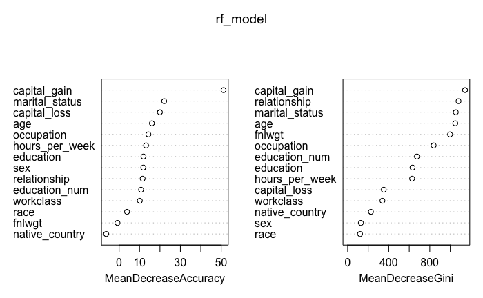

```r
varImpPlot(rf_model)
```

#### (vii) The number of variables tried at each split is 3.

```r
print(rf_model)
```

```
Call:
 randomForest(formula = income ~ ., data = pure_train, ntree = 100,      importance = T)
               Type of random forest: classification
                     Number of trees: 100
No. of variables tried at each split: 3

        OOB estimate of  error rate: 18.08%
Confusion matrix:
      <=50K >50K class.error
<=50K 22545  108   0.0047676
>50K   5346 2162   0.7120405
```

### (b)

```
mtry = 3  OOB error = 18.19%
Searching left ...
mtry = 2    OOB error = 18.1%
0.0049225 0.01
Searching right ...
mtry = 4    OOB error = 18.19%
-0.00018232 0.01
```

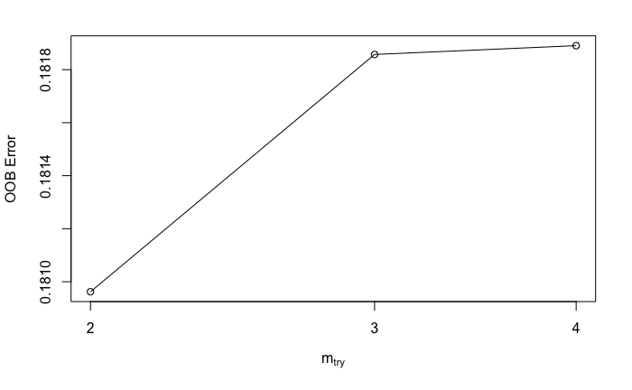

```r
mtry <- tuneRF(pure_train[,-15], pure_train$income, ntreeTry=500, stepFactor=1.5,improve=0.01, trace=TRUE, plot=TRUE)
```

#### (i) The default value of mtry given the number of predictors in the model is 3.

#### (ii) The optimal value of mtry suggested by the method is 2.

#### (iii)

```r
new_rf_model <- randomForest(income ~ ., data=pure_train, importance = T, mtry = 2)
new_rf_pred <- predict(new_rf_model, pure_test, type="class")
confusionMatrix(new_rf_pred, as.factor(pure_test$income))
```

```
Confusion Matrix and Statistics

          Reference
Prediction <=50K  >50K
     <=50K 11319  2615
     >50K     41  1085

               Accuracy : 0.824
                 95% CI : (0.817, 0.83)
    No Information Rate : 0.754
    P-Value [Acc > NIR] : <2e-16

                  Kappa : 0.378
 Mcnemar's Test P-Value : <2e-16

            Sensitivity : 0.996
            Specificity : 0.293
         Pos Pred Value : 0.812
         Neg Pred Value : 0.964
             Prevalence : 0.754
         Detection Rate : 0.752
   Detection Prevalence : 0.925
      Balanced Accuracy : 0.645

       'Positive' Class : <=50K
```

###### (1) The balanced accuracy of the model is ~0.645.

###### (2) The accuracy of the model is ~0.824.

###### (3) Sensitivity : ~0.996 Specificity : ~0.293

###### (5)

###### For MeanDecreaseAccuracy, capital_gain is the most important variable and native_country is the least importatn variable.

###### For MeanDecreaseGini, capital_gain is the most important variable and race is the least importatn variable.

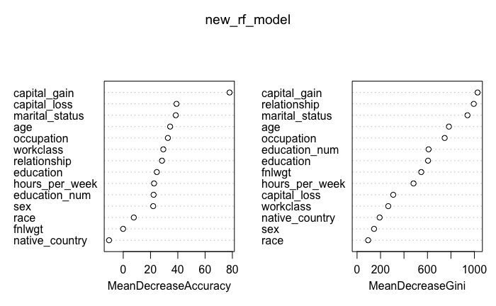

```r
varImpPlot(new_rf_model)
```

#### In(b): The Accuracy of the model is ~0.824, Balanced accuracy is ~0.645, the Sensitivity is ~0.996 and the Specificity is ~0.293.

```r
bal_rf_model <- randomForest(income ~ ., data=new_train, importance = T)
bal_rf_pred <- predict(bal_rf_model, pure_test, type="class")
confusionMatrix(bal_rf_pred, as.factor(pure_test$income))
```

[output not shown]

# 2.3

```r
library(arules)
library(arulesViz)
library(viridisLite)
groceries <- read.transactions("groceries.csv", sep = ",")
```

### (i)

```r
rules <- apriori(groceries)
```

```
Apriori

Parameter specification:
 confidence minval smax arem  aval originalSupport maxtime support minlen maxlen target   ext
        0.8    0.1    1 none FALSE            TRUE       5     0.1      1     10  rules FALSE

Algorithmic control:
 filter tree heap memopt load sort verbose
    0.1 TRUE TRUE  FALSE TRUE    2    TRUE

Absolute minimum support count: 983

set item appearances ...[0 item(s)] done [0.00s].
set transactions ...[169 item(s), 9835 transaction(s)] done [0.00s].
sorting and recoding items ... [8 item(s)] done [0.00s].
creating transaction tree ... done [0.00s].
checking subsets of size 1 2 done [0.00s].
writing ... [0 rule(s)] done [0.00s].
creating S4 object  ... done [0.00s].
```

#### 0 rules I get at this support value.

### (ii)

```r
rules_1 <- apriori(groceries, parameter = list(support=0.001))
```

```
Apriori

Parameter specification:
 confidence minval smax arem  aval originalSupport maxtime support minlen maxlen target   ext
        0.8    0.1    1 none FALSE            TRUE       5   0.001      1     10  rules FALSE

Algorithmic control:
 filter tree heap memopt load sort verbose
    0.1 TRUE TRUE  FALSE TRUE    2    TRUE

Absolute minimum support count: 9

set item appearances ...[0 item(s)] done [0.00s].
set transactions ...[169 item(s), 9835 transaction(s)] done [0.00s].
sorting and recoding items ... [157 item(s)] done [0.00s].
creating transaction tree ... done [0.00s].
checking subsets of size 1 2 3 4 5 6 done [0.01s].
writing ... [410 rule(s)] done [0.00s].
creating S4 object  ... done [0.00s].
```

#### Support value is 0.001 when get at least 400 rules.

### (iii)

```r
summary(groceries)
```

```
transactions as itemMatrix in sparse format with
 9835 rows (elements/itemsets/transactions) and
 169 columns (items) and a density of 0.02609146

most frequent items:
      whole milk other vegetables       rolls/buns             soda           yogurt          (Other)
            2513             1903             1809             1715             1372            34055

element (itemset/transaction) length distribution:
sizes
   1    2    3    4    5    6    7    8    9   10   11   12   13   14   15   16   17   18   19   20   21   22   23   24   26   27   28   29   32
2159 1643 1299 1005  855  645  545  438  350  246  182  117   78   77   55   46   29   14   14    9   11    4    6    1    1    1    1    3    1

   Min. 1st Qu.  Median    Mean 3rd Qu.    Max.
  1.000   2.000   3.000   4.409   6.000  32.000

includes extended item information - examples:
            labels
1 abrasive cleaner
2 artif. sweetener
3   baby cosmetics
```

```r
sort(itemFrequency(groceries),decreasing = T)
```

```
               whole milk          other vegetables                rolls/buns                      soda                    yogurt
             0.2555160142              0.1934926284              0.1839349263              0.1743772242              0.1395017794
            bottled water           root vegetables            tropical fruit             shopping bags                   sausage
             0.1105236401              0.1089984748              0.1049313676              0.0985256736              0.0939501779
                   pastry              citrus fruit              bottled beer                newspapers               canned beer
             0.0889679715              0.0827656329              0.0805287239              0.0798169802              0.0776817489
                pip fruit     fruit/vegetable juice        whipped/sour cream               brown bread             domestic eggs
             0.0756481952              0.0722928317              0.0716827656              0.0648703610              0.0634468734
              frankfurter                 margarine                    coffee                      pork                    butter
             0.0589730554              0.0585663447              0.0580579563              0.0576512456              0.0554143366
                     curd                      beef                   napkins                 chocolate         frozen vegetables
             0.0532791052              0.0524656838              0.0523640061              0.0496187087              0.0480935435
                  chicken               white bread              cream cheese                   waffles               salty snack
             0.0429079817              0.0420945602              0.0396542959              0.0384341637              0.0378240976
 long life bakery product                   dessert                     sugar                  UHT-milk                   berries
             0.0374173869              0.0371123538              0.0338586680              0.0334519573              0.0332486019
           hamburger meat          hygiene articles                    onions       specialty chocolate                     candy
             0.0332486019              0.0329435689              0.0310116929              0.0304016268              0.0298932384
             frozen meals           misc. beverages                       oil               butter milk             specialty bar
             0.0283680732              0.0283680732              0.0280630402              0.0279613625              0.0273512964
                beverages                       ham                      meat                 ice cream               hard cheese
             0.0260294865              0.0260294865              0.0258261312              0.0250127097              0.0245043213
            sliced cheese                  cat food                    grapes               chewing gum                 detergent
             0.0245043213              0.0232841891              0.0223690900              0.0210472801              0.0192170819
           red/blush wine                white wine        pickled vegetables             baking powder       semi-finished bread
             0.0192170819              0.0190137265              0.0178952720              0.0176919166              0.0176919166
                   dishes                     flour                pot plants               soft cheese          processed cheese
             0.0175902389              0.0173868836              0.0172852059              0.0170818505              0.0165734621
                    herbs               canned fish                     pasta         seasonal products                  cake bar
             0.0162684291              0.0150482969              0.0150482969              0.0142348754              0.0132180986
packaged fruit/vegetables                   mustard               frozen fish           cling film/bags             spread cheese
             0.0130147433              0.0119979664              0.0116929334              0.0113879004              0.0111845450
                   liquor         canned vegetables            frozen dessert                      salt              dish cleaner
             0.0110828673              0.0107778343              0.0107778343              0.0107778343              0.0104728012
           flower (seeds)            condensed milk             roll products                  pet care                photo/film
             0.0103711235              0.0102694459              0.0102694459              0.0094560244              0.0092526690
               mayonnaise     chocolate marshmallow             sweet spreads                   candles                  dog food
             0.0091509914              0.0090493137              0.0090493137              0.0089476360              0.0085409253
         specialty cheese    frozen potato products    house keeping products                    turkey     Instant food products
             0.0085409253              0.0084392476              0.0083375699              0.0081342145              0.0080325369
```

[output cut: 13 more lines]

```
             0.0033553635              0.0032536858              0.0032536858              0.0032536858              0.0031520081
           snack products                      fish           potato products          bathroom cleaner                  cookware
             0.0030503305              0.0029486528              0.0028469751              0.0027452974              0.0027452974
                     soap         cooking chocolate            pudding powder                   tidbits              cocoa drinks
             0.0026436197              0.0025419420              0.0023385867              0.0023385867              0.0022369090
          organic sausage                  prosecco    flower soil/fertilizer               ready soups      specialty vegetables
             0.0022369090              0.0020335536              0.0019318760              0.0018301983              0.0017285206
         organic products               decalcifier                     honey                     cream             frozen fruits
             0.0016268429              0.0015251652              0.0015251652              0.0013218099              0.0012201322
               hair spray           rubbing alcohol                   liqueur           make up remover            salad dressing
             0.0011184545              0.0010167768              0.0009150991              0.0008134215              0.0008134215
                   whisky            toilet cleaner            baby cosmetics            frozen chicken                      bags
             0.0008134215              0.0007117438              0.0006100661              0.0006100661              0.0004067107
          kitchen utensil     preservation products                 baby food      sound storage medium
             0.0004067107              0.0002033554              0.0001016777              0.0001016777
```

#### The most frequently bought item is whole milk. Whole milk’s frequency is 0.2555160142.

### (iv)

#### The least frequently bought item is sound storage medium. And its frequency is 0.0001016777.

### (v)

```r
inspect(head(rules_1, by = "support",5))
```

```
    lhs                                                         rhs                support     confidence lift     count
[1] {citrus fruit,root vegetables,tropical fruit,whole milk} => {other vegetables} 0.003152008 0.8857143  4.577509 31
[2] {curd,domestic eggs,other vegetables}                    => {whole milk}       0.002846975 0.8235294  3.223005 28
[3] {curd,hamburger meat}                                    => {whole milk}       0.002541942 0.8064516  3.156169 25
[4] {herbs,rolls/buns}                                       => {whole milk}       0.002440264 0.8000000  3.130919 24
[5] {herbs,tropical fruit}                                   => {whole milk}       0.002338587 0.8214286  3.214783 23
```

### (vi)

```r
inspect(head(rules_1, by = "confidence",5))
```

```
    lhs                                           rhs          support     confidence lift     count
[1] {rice,sugar}                               => {whole milk} 0.001220132 1          3.913649 12
[2] {canned fish,hygiene articles}             => {whole milk} 0.001118454 1          3.913649 11
[3] {butter,rice,root vegetables}              => {whole milk} 0.001016777 1          3.913649 10
[4] {flour,root vegetables,whipped/sour cream} => {whole milk} 0.001728521 1          3.913649 17
[5] {butter,domestic eggs,soft cheese}         => {whole milk} 0.001016777 1          3.913649 10
```

### (vii)

```r
inspect(tail(rules_1, by = "support",5))
```

```
    lhs                                                                          rhs                support     confidence lift     count
[1] {oil,other vegetables,tropical fruit,whole milk,yogurt}                   => {root vegetables}  0.001016777 0.9090909  8.340400 10
[2] {butter,domestic eggs,other vegetables,tropical fruit,yogurt}             => {whole milk}       0.001016777 0.9090909  3.557863 10
[3] {butter,domestic eggs,tropical fruit,whole milk,yogurt}                   => {other vegetables} 0.001016777 0.8333333  4.306796 10
[4] {citrus fruit,other vegetables,root vegetables,whipped/sour cream,yogurt} => {whole milk}       0.001016777 0.8333333  3.261374 10
[5] {citrus fruit,root vegetables,whipped/sour cream,whole milk,yogurt}       => {other vegetables} 0.001016777 0.9090909  4.698323 10
```

### (viii)

```r
inspect(tail(rules_1, by = "confidence",5))
```

```
    lhs                                                               rhs                support     confidence lift     count
[1] {pip fruit,tropical fruit,whipped/sour cream,whole milk}       => {other vegetables} 0.001626843 0.8        4.134524 16
[2] {citrus fruit,other vegetables,sausage,whipped/sour cream}     => {whole milk}       0.001220132 0.8        3.130919 12
[3] {citrus fruit,sausage,whipped/sour cream,whole milk}           => {other vegetables} 0.001220132 0.8        4.134524 12
[4] {citrus fruit,tropical fruit,whipped/sour cream,yogurt}        => {whole milk}       0.001220132 0.8        3.130919 12
[5] {rolls/buns,root vegetables,tropical fruit,whipped/sour cream} => {other vegetables} 0.001220132 0.8        4.134524 12
```